# Risk Factor Analysis

## Outcome Variable

**Outcome Variable:** stunted

## Predictor Variables

**Intervention Variable:** tr

**Adjustment Set:**

unadjusted

## Stratifying Variables

The analysis was stratified on these variable(s):

- agecat
- studyid
- country
- intXmhtcm

## Data Summary

| agecat | studyid | country | intXmhtcm | stunted | n_cell | n |
| --- | --- | --- | --- | --- | --- | --- |
| Birth | iLiNS_DYADM_LNS | MALAWI | <151 cm_Birth | 0 | 0 | 1 |
| Birth | iLiNS_DYADM_LNS | MALAWI | <151 cm_Birth | 1 | 1 | 1 |
| Birth | ki1000125-AgaKhanUniv | PAKISTAN | >=155 cm_Birth | 0 | 3 | 3 |
| Birth | ki1000125-AgaKhanUniv | PAKISTAN | >=155 cm_Birth | 1 | 0 | 3 |
| Birth | ki1000125-AgaKhanUniv | PAKISTAN | <151 cm_Birth | 0 | 1 | 1 |
| Birth | ki1000125-AgaKhanUniv | PAKISTAN | <151 cm_Birth | 1 | 0 | 1 |
| Birth | ki1000304b-SAS-CompFeed | INDIA | >=155 cm_Birth | 0 | 33 | 43 |
| Birth | ki1000304b-SAS-CompFeed | INDIA | >=155 cm_Birth | 1 | 10 | 43 |
| Birth | ki1000304b-SAS-CompFeed | INDIA | <151 cm_Birth | 0 | 12 | 21 |
| Birth | ki1000304b-SAS-CompFeed | INDIA | <151 cm_Birth | 1 | 9 | 21 |
| Birth | ki1000304b-SAS-CompFeed | INDIA | [151-155) cm_Birth | 0 | 16 | 25 |
| Birth | ki1000304b-SAS-CompFeed | INDIA | [151-155) cm_Birth | 1 | 9 | 25 |
| Birth | ki1119695-PROBIT | BELARUS | >=155 cm_Birth | 0 | 13174 | 13206 |
| Birth | ki1119695-PROBIT | BELARUS | >=155 cm_Birth | 1 | 32 | 13206 |
| Birth | ki1119695-PROBIT | BELARUS | <151 cm_Birth | 0 | 125 | 125 |
| Birth | ki1119695-PROBIT | BELARUS | <151 cm_Birth | 1 | 0 | 125 |
| Birth | ki1119695-PROBIT | BELARUS | [151-155) cm_Birth | 0 | 397 | 398 |
| Birth | ki1119695-PROBIT | BELARUS | [151-155) cm_Birth | 1 | 1 | 398 |
| Birth | ki1126311-ZVITAMBO | ZIMBABWE | >=155 cm_Birth | 0 | 6977 | 7704 |
| Birth | ki1126311-ZVITAMBO | ZIMBABWE | >=155 cm_Birth | 1 | 727 | 7704 |
| Birth | ki1126311-ZVITAMBO | ZIMBABWE | <151 cm_Birth | 0 | 480 | 558 |
| Birth | ki1126311-ZVITAMBO | ZIMBABWE | <151 cm_Birth | 1 | 78 | 558 |
| Birth | ki1126311-ZVITAMBO | ZIMBABWE | [151-155) cm_Birth | 0 | 1252 | 1405 |
| Birth | ki1126311-ZVITAMBO | ZIMBABWE | [151-155) cm_Birth | 1 | 153 | 1405 |
| Birth | ki1135781-COHORTS | GUATEMALA | >=155 cm_Birth | 0 | 104 | 110 |
| Birth | ki1135781-COHORTS | GUATEMALA | >=155 cm_Birth | 1 | 6 | 110 |
| Birth | ki1135781-COHORTS | GUATEMALA | <151 cm_Birth | 0 | 513 | 545 |
| Birth | ki1135781-COHORTS | GUATEMALA | <151 cm_Birth | 1 | 32 | 545 |
| Birth | ki1135781-COHORTS | GUATEMALA | [151-155) cm_Birth | 0 | 174 | 185 |
| Birth | ki1135781-COHORTS | GUATEMALA | [151-155) cm_Birth | 1 | 11 | 185 |

[output cut: 168 more lines]

The following strata were considered:

- agecat: 24 months, studyid: ki1000110-WASH-Bangladesh, country: BANGLADESH, intXmhtcm: [151-155) cm_24 months
- agecat: 24 months, studyid: ki1000110-WASH-Bangladesh, country: BANGLADESH, intXmhtcm: <151 cm_24 months
- agecat: 24 months, studyid: ki1000110-WASH-Bangladesh, country: BANGLADESH, intXmhtcm: >=155 cm_24 months
- agecat: 24 months, studyid: ki1000111-WASH-Kenya, country: KENYA, intXmhtcm: [151-155) cm_24 months
- agecat: 24 months, studyid: ki1000111-WASH-Kenya, country: KENYA, intXmhtcm: <151 cm_24 months
- agecat: 24 months, studyid: ki1000111-WASH-Kenya, country: KENYA, intXmhtcm: >=155 cm_24 months
- agecat: 24 months, studyid: ki1017093b-PROVIDE, country: BANGLADESH, intXmhtcm: [151-155) cm_24 months
- agecat: 24 months, studyid: ki1066203-TanzaniaChild2, country: TANZANIA, UNITED REPUBLIC OF, intXmhtcm: [151-155) cm_24 months
- agecat: 24 months, studyid: ki1066203-TanzaniaChild2, country: TANZANIA, UNITED REPUBLIC OF, intXmhtcm: <151 cm_24 months
- agecat: 24 months, studyid: ki1066203-TanzaniaChild2, country: TANZANIA, UNITED REPUBLIC OF, intXmhtcm: >=155 cm_24 months
- agecat: 24 months, studyid: ki1112895-Burkina Faso Zn, country: BURKINA FASO, intXmhtcm: [151-155) cm_24 months
- agecat: 24 months, studyid: ki1112895-Burkina Faso Zn, country: BURKINA FASO, intXmhtcm: <151 cm_24 months
- agecat: 24 months, studyid: ki1112895-Burkina Faso Zn, country: BURKINA FASO, intXmhtcm: >=155 cm_24 months
- agecat: 24 months, studyid: ki1119695-PROBIT, country: BELARUS, intXmhtcm: [151-155) cm_24 months
- agecat: 24 months, studyid: ki1119695-PROBIT, country: BELARUS, intXmhtcm: <151 cm_24 months
- agecat: 24 months, studyid: ki1119695-PROBIT, country: BELARUS, intXmhtcm: >=155 cm_24 months
- agecat: 24 months, studyid: ki1126311-ZVITAMBO, country: ZIMBABWE, intXmhtcm: [151-155) cm_24 months
- agecat: 24 months, studyid: ki1126311-ZVITAMBO, country: ZIMBABWE, intXmhtcm: <151 cm_24 months
- agecat: 24 months, studyid: ki1126311-ZVITAMBO, country: ZIMBABWE, intXmhtcm: >=155 cm_24 months
- agecat: 24 months, studyid: ki1135781-COHORTS, country: GUATEMALA, intXmhtcm: [151-155) cm_24 months
- agecat: 24 months, studyid: ki1135781-COHORTS, country: GUATEMALA, intXmhtcm: <151 cm_24 months
- agecat: 24 months, studyid: ki1135781-COHORTS, country: GUATEMALA, intXmhtcm: >=155 cm_24 months
- agecat: 24 months, studyid: ki1148112-iLiNS-DOSE, country: MALAWI, intXmhtcm: [151-155) cm_24 months
- agecat: 24 months, studyid: ki1148112-iLiNS-DOSE, country: MALAWI, intXmhtcm: <151 cm_24 months
- agecat: 24 months, studyid: ki1148112-iLiNS-DOSE, country: MALAWI, intXmhtcm: >=155 cm_24 months
- agecat: 24 months, studyid: ki1148112-LCNI-5, country: MALAWI, intXmhtcm: [151-155) cm_24 months
- agecat: 24 months, studyid: ki1148112-LCNI-5, country: MALAWI, intXmhtcm: <151 cm_24 months
- agecat: 24 months, studyid: ki1148112-LCNI-5, country: MALAWI, intXmhtcm: >=155 cm_24 months
- agecat: 24 months, studyid: kiGH5241-JiVitA-3, country: BANGLADESH, intXmhtcm: [151-155) cm_24 months
- agecat: 24 months, studyid: kiGH5241-JiVitA-3, country: BANGLADESH, intXmhtcm: <151 cm_24 months
- agecat: 24 months, studyid: kiGH5241-JiVitA-3, country: BANGLADESH, intXmhtcm: >=155 cm_24 months
- agecat: 6 months, studyid: iLiNS_DYADM_LNS, country: MALAWI, intXmhtcm: [151-155) cm_6 months
- agecat: 6 months, studyid: iLiNS_DYADM_LNS, country: MALAWI, intXmhtcm: <151 cm_6 months
- agecat: 6 months, studyid: ki1000110-WASH-Bangladesh, country: BANGLADESH, intXmhtcm: [151-155) cm_6 months
- agecat: 6 months, studyid: ki1000110-WASH-Bangladesh, country: BANGLADESH, intXmhtcm: <151 cm_6 months
- agecat: 6 months, studyid: ki1000110-WASH-Bangladesh, country: BANGLADESH, intXmhtcm: >=155 cm_6 months
- agecat: 6 months, studyid: ki1000111-WASH-Kenya, country: KENYA, intXmhtcm: [151-155) cm_6 months
- agecat: 6 months, studyid: ki1000111-WASH-Kenya, country: KENYA, intXmhtcm: <151 cm_6 months
- agecat: 6 months, studyid: ki1000111-WASH-Kenya, country: KENYA, intXmhtcm: >=155 cm_6 months
- agecat: 6 months, studyid: ki1000125-AgaKhanUniv, country: PAKISTAN, intXmhtcm: [151-155) cm_6 months
- agecat: 6 months, studyid: ki1000125-AgaKhanUniv, country: PAKISTAN, intXmhtcm: <151 cm_6 months
- agecat: 6 months, studyid: ki1000125-AgaKhanUniv, country: PAKISTAN, intXmhtcm: >=155 cm_6 months
- agecat: 6 months, studyid: ki1000304b-SAS-CompFeed, country: INDIA, intXmhtcm: [151-155) cm_6 months
- agecat: 6 months, studyid: ki1000304b-SAS-CompFeed, country: INDIA, intXmhtcm: <151 cm_6 months
- agecat: 6 months, studyid: ki1000304b-SAS-CompFeed, country: INDIA, intXmhtcm: >=155 cm_6 months
- agecat: 6 months, studyid: ki1000304b-SAS-FoodSuppl, country: INDIA, intXmhtcm: [151-155) cm_6 months
- agecat: 6 months, studyid: ki1000304b-SAS-FoodSuppl, country: INDIA, intXmhtcm: <151 cm_6 months
- agecat: 6 months, studyid: ki1000304b-SAS-FoodSuppl, country: INDIA, intXmhtcm: >=155 cm_6 months
- agecat: 6 months, studyid: ki1017093b-PROVIDE, country: BANGLADESH, intXmhtcm: [151-155) cm_6 months
- agecat: 6 months, studyid: ki1017093b-PROVIDE, country: BANGLADESH, intXmhtcm: <151 cm_6 months
- agecat: 6 months, studyid: ki1017093b-PROVIDE, country: BANGLADESH, intXmhtcm: >=155 cm_6 months
- agecat: 6 months, studyid: ki1066203-TanzaniaChild2, country: TANZANIA, UNITED REPUBLIC OF, intXmhtcm: [151-155) cm_6 months
- agecat: 6 months, studyid: ki1066203-TanzaniaChild2, country: TANZANIA, UNITED REPUBLIC OF, intXmhtcm: <151 cm_6 months
- agecat: 6 months, studyid: ki1066203-TanzaniaChild2, country: TANZANIA, UNITED REPUBLIC OF, intXmhtcm: >=155 cm_6 months
- agecat: 6 months, studyid: ki1112895-Burkina Faso Zn, country: BURKINA FASO, intXmhtcm: [151-155) cm_6 months
- agecat: 6 months, studyid: ki1112895-Burkina Faso Zn, country: BURKINA FASO, intXmhtcm: <151 cm_6 months
- agecat: 6 months, studyid: ki1112895-Burkina Faso Zn, country: BURKINA FASO, intXmhtcm: >=155 cm_6 months
- agecat: 6 months, studyid: ki1112895-Guatemala BSC, country: GUATEMALA, intXmhtcm: [151-155) cm_6 months
- agecat: 6 months, studyid: ki1112895-Guatemala BSC, country: GUATEMALA, intXmhtcm: <151 cm_6 months
- agecat: 6 months, studyid: ki1112895-Guatemala BSC, country: GUATEMALA, intXmhtcm: >=155 cm_6 months
- agecat: 6 months, studyid: ki1119695-PROBIT, country: BELARUS, intXmhtcm: [151-155) cm_6 months
- agecat: 6 months, studyid: ki1119695-PROBIT, country: BELARUS, intXmhtcm: <151 cm_6 months
- agecat: 6 months, studyid: ki1119695-PROBIT, country: BELARUS, intXmhtcm: >=155 cm_6 months
- agecat: 6 months, studyid: ki1126311-ZVITAMBO, country: ZIMBABWE, intXmhtcm: [151-155) cm_6 months
- agecat: 6 months, studyid: ki1126311-ZVITAMBO, country: ZIMBABWE, intXmhtcm: <151 cm_6 months
- agecat: 6 months, studyid: ki1126311-ZVITAMBO, country: ZIMBABWE, intXmhtcm: >=155 cm_6 months
- agecat: 6 months, studyid: ki1135781-COHORTS, country: GUATEMALA, intXmhtcm: [151-155) cm_6 months
- agecat: 6 months, studyid: ki1135781-COHORTS, country: GUATEMALA, intXmhtcm: <151 cm_6 months
- agecat: 6 months, studyid: ki1135781-COHORTS, country: GUATEMALA, intXmhtcm: >=155 cm_6 months
- agecat: 6 months, studyid: ki1148112-iLiNS-DOSE, country: MALAWI, intXmhtcm: [151-155) cm_6 months
- agecat: 6 months, studyid: ki1148112-iLiNS-DOSE, country: MALAWI, intXmhtcm: <151 cm_6 months
- agecat: 6 months, studyid: ki1148112-iLiNS-DOSE, country: MALAWI, intXmhtcm: >=155 cm_6 months
- agecat: 6 months, studyid: ki1148112-iLiNS-DYAD-M, country: MALAWI, intXmhtcm: [151-155) cm_6 months
- agecat: 6 months, studyid: ki1148112-iLiNS-DYAD-M, country: MALAWI, intXmhtcm: <151 cm_6 months
- agecat: 6 months, studyid: ki1148112-LCNI-5, country: MALAWI, intXmhtcm: [151-155) cm_6 months
- agecat: 6 months, studyid: ki1148112-LCNI-5, country: MALAWI, intXmhtcm: <151 cm_6 months
- agecat: 6 months, studyid: ki1148112-LCNI-5, country: MALAWI, intXmhtcm: >=155 cm_6 months
- agecat: 6 months, studyid: kiGH5241-JiVitA-3, country: BANGLADESH, intXmhtcm: [151-155) cm_6 months
- agecat: 6 months, studyid: kiGH5241-JiVitA-3, country: BANGLADESH, intXmhtcm: <151 cm_6 months
- agecat: 6 months, studyid: kiGH5241-JiVitA-3, country: BANGLADESH, intXmhtcm: >=155 cm_6 months
- agecat: Birth, studyid: iLiNS_DYADM_LNS, country: MALAWI, intXmhtcm: <151 cm_Birth
- agecat: Birth, studyid: ki1000125-AgaKhanUniv, country: PAKISTAN, intXmhtcm: <151 cm_Birth
- agecat: Birth, studyid: ki1000125-AgaKhanUniv, country: PAKISTAN, intXmhtcm: >=155 cm_Birth
- agecat: Birth, studyid: ki1000304b-SAS-CompFeed, country: INDIA, intXmhtcm: [151-155) cm_Birth
- agecat: Birth, studyid: ki1000304b-SAS-CompFeed, country: INDIA, intXmhtcm: <151 cm_Birth
- agecat: Birth, studyid: ki1000304b-SAS-CompFeed, country: INDIA, intXmhtcm: >=155 cm_Birth
- agecat: Birth, studyid: ki1119695-PROBIT, country: BELARUS, intXmhtcm: [151-155) cm_Birth
- agecat: Birth, studyid: ki1119695-PROBIT, country: BELARUS, intXmhtcm: <151 cm_Birth
- agecat: Birth, studyid: ki1119695-PROBIT, country: BELARUS, intXmhtcm: >=155 cm_Birth
- agecat: Birth, studyid: ki1126311-ZVITAMBO, country: ZIMBABWE, intXmhtcm: [151-155) cm_Birth
- agecat: Birth, studyid: ki1126311-ZVITAMBO, country: ZIMBABWE, intXmhtcm: <151 cm_Birth
- agecat: Birth, studyid: ki1126311-ZVITAMBO, country: ZIMBABWE, intXmhtcm: >=155 cm_Birth
- agecat: Birth, studyid: ki1135781-COHORTS, country: GUATEMALA, intXmhtcm: [151-155) cm_Birth
- agecat: Birth, studyid: ki1135781-COHORTS, country: GUATEMALA, intXmhtcm: <151 cm_Birth
- agecat: Birth, studyid: ki1135781-COHORTS, country: GUATEMALA, intXmhtcm: >=155 cm_Birth
- agecat: Birth, studyid: ki1148112-iLiNS-DYAD-M, country: MALAWI, intXmhtcm: <151 cm_Birth
- agecat: Birth, studyid: kiGH5241-JiVitA-3, country: BANGLADESH, intXmhtcm: [151-155) cm_Birth
- agecat: Birth, studyid: kiGH5241-JiVitA-3, country: BANGLADESH, intXmhtcm: <151 cm_Birth
- agecat: Birth, studyid: kiGH5241-JiVitA-3, country: BANGLADESH, intXmhtcm: >=155 cm_Birth

### Dropped Strata

Some strata were dropped due to rare outcomes:

- agecat: Birth, studyid: iLiNS_DYADM_LNS, country: MALAWI, intXmhtcm: <151 cm_Birth
- agecat: Birth, studyid: ki1000125-AgaKhanUniv, country: PAKISTAN, intXmhtcm: >=155 cm_Birth
- agecat: Birth, studyid: ki1000125-AgaKhanUniv, country: PAKISTAN, intXmhtcm: <151 cm_Birth
- agecat: Birth, studyid: ki1119695-PROBIT, country: BELARUS, intXmhtcm: <151 cm_Birth
- agecat: Birth, studyid: ki1119695-PROBIT, country: BELARUS, intXmhtcm: [151-155) cm_Birth
- agecat: Birth, studyid: ki1148112-iLiNS-DYAD-M, country: MALAWI, intXmhtcm: <151 cm_Birth
- agecat: 6 months, studyid: iLiNS_DYADM_LNS, country: MALAWI, intXmhtcm: <151 cm_6 months
- agecat: 6 months, studyid: iLiNS_DYADM_LNS, country: MALAWI, intXmhtcm: [151-155) cm_6 months
- agecat: 6 months, studyid: ki1000111-WASH-Kenya, country: KENYA, intXmhtcm: <151 cm_6 months
- agecat: 6 months, studyid: ki1000111-WASH-Kenya, country: KENYA, intXmhtcm: [151-155) cm_6 months
- agecat: 6 months, studyid: ki1017093b-PROVIDE, country: BANGLADESH, intXmhtcm: >=155 cm_6 months
- agecat: 6 months, studyid: ki1017093b-PROVIDE, country: BANGLADESH, intXmhtcm: <151 cm_6 months
- agecat: 6 months, studyid: ki1017093b-PROVIDE, country: BANGLADESH, intXmhtcm: [151-155) cm_6 months
- agecat: 6 months, studyid: ki1148112-iLiNS-DYAD-M, country: MALAWI, intXmhtcm: <151 cm_6 months
- agecat: 6 months, studyid: ki1148112-iLiNS-DYAD-M, country: MALAWI, intXmhtcm: [151-155) cm_6 months
- agecat: 24 months, studyid: ki1017093b-PROVIDE, country: BANGLADESH, intXmhtcm: [151-155) cm_24 months
- agecat: 24 months, studyid: ki1066203-TanzaniaChild2, country: TANZANIA, UNITED REPUBLIC OF, intXmhtcm: >=155 cm_24 months
- agecat: 24 months, studyid: ki1066203-TanzaniaChild2, country: TANZANIA, UNITED REPUBLIC OF, intXmhtcm: <151 cm_24 months
- agecat: 24 months, studyid: ki1066203-TanzaniaChild2, country: TANZANIA, UNITED REPUBLIC OF, intXmhtcm: [151-155) cm_24 months
- agecat: 24 months, studyid: ki1119695-PROBIT, country: BELARUS, intXmhtcm: [151-155) cm_24 months
- agecat: 24 months, studyid: ki1126311-ZVITAMBO, country: ZIMBABWE, intXmhtcm: <151 cm_24 months
- agecat: 24 months, studyid: ki1126311-ZVITAMBO, country: ZIMBABWE, intXmhtcm: [151-155) cm_24 months

## Methods Detail

We’re interested in the causal parameters $E[Y_a]$ for all values of $a \in \mathcal{A}$. These parameters represent the mean outcome if, possibly contrary to fact, we intervened to set all units to have $A=a$. Under the randomization and positivity assumptions, these are identified by the statistical parameters $\psi_a=E_W[E_{Y|A,W}(Y|A=a,W)]$. In addition, we’re interested in the mean of $Y$, $E[Y]$ under no intervention (the observed mean). We will estimate these parameters by using SuperLearner to fit the relevant likelihood factors – $E_{Y|A,W}(Y|A=a,W)$ and $p(A=a|W)$, and then updating our likelihood fit using a joint TMLE.

For unadjusted analyses ($W=\{\}$), initial likelihoods were estimated using Lrnr_glm to estimate the simple $E(Y|A)$ and Lrnr_mean to estimate $p(A)$. For adjusted analyses, a small library containing Lrnr_glmnet, Lrnr_xgboost, and Lrnr_mean was used.

Having estimated these parameters, we will then use the delta method to estimate relative risks and attributable risks relative to a prespecified baseline level of $A$.

[output not shown]

# Results Detail

## Results Plots

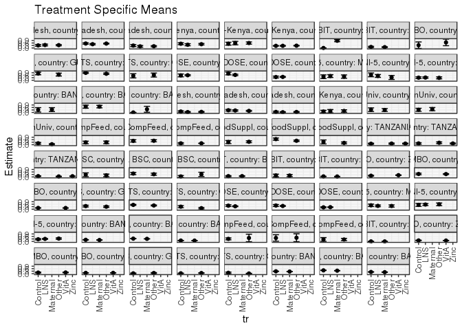

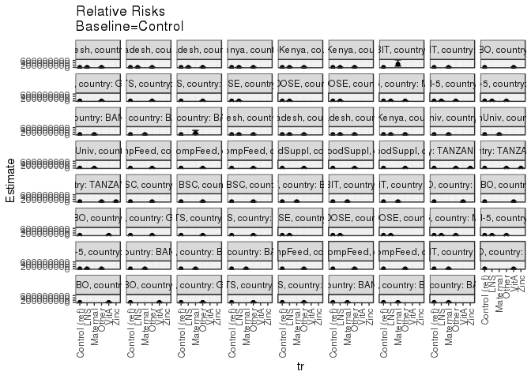

[figure not shown]

[figure not shown]

## Results Table

### Parameter: TSM

| agecat | studyid | country | intXmhtcm | intervention_level | baseline_level | estimate | ci_lower | ci_upper |
| --- | --- | --- | --- | --- | --- | --- | --- | --- |
| Birth | ki1000304b-SAS-CompFeed | INDIA | >=155 cm_Birth | Control | NA | 0.2352941 | 0.0109003 | 0.4596880 |
| Birth | ki1000304b-SAS-CompFeed | INDIA | >=155 cm_Birth | Other | NA | 0.2307692 | 0.0918127 | 0.3697258 |
| Birth | ki1000304b-SAS-CompFeed | INDIA | <151 cm_Birth | Control | NA | 0.4166667 | 0.0271487 | 0.8061847 |
| Birth | ki1000304b-SAS-CompFeed | INDIA | <151 cm_Birth | Other | NA | 0.4444444 | -0.0298354 | 0.9187243 |
| Birth | ki1000304b-SAS-CompFeed | INDIA | [151-155) cm_Birth | Control | NA | 0.3076923 | 0.1928643 | 0.4225203 |
| Birth | ki1000304b-SAS-CompFeed | INDIA | [151-155) cm_Birth | Other | NA | 0.4166667 | -0.0347545 | 0.8680879 |
| Birth | ki1119695-PROBIT | BELARUS | >=155 cm_Birth | Control | NA | 0.0032594 | 0.0009324 | 0.0055863 |
| Birth | ki1119695-PROBIT | BELARUS | >=155 cm_Birth | Maternal | NA | 0.0016265 | 0.0004597 | 0.0027933 |
| Birth | ki1126311-ZVITAMBO | ZIMBABWE | >=155 cm_Birth | Control | NA | 0.0926119 | 0.0796511 | 0.1055726 |
| Birth | ki1126311-ZVITAMBO | ZIMBABWE | >=155 cm_Birth | VitA | NA | 0.0949498 | 0.0873933 | 0.1025063 |
| Birth | ki1126311-ZVITAMBO | ZIMBABWE | <151 cm_Birth | Control | NA | 0.1304348 | 0.0741947 | 0.1866749 |
| Birth | ki1126311-ZVITAMBO | ZIMBABWE | <151 cm_Birth | VitA | NA | 0.1428571 | 0.1093613 | 0.1763530 |
| Birth | ki1126311-ZVITAMBO | ZIMBABWE | [151-155) cm_Birth | Control | NA | 0.1171171 | 0.0825676 | 0.1516667 |
| Birth | ki1126311-ZVITAMBO | ZIMBABWE | [151-155) cm_Birth | VitA | NA | 0.1063433 | 0.0878827 | 0.1248039 |
| Birth | ki1135781-COHORTS | GUATEMALA | >=155 cm_Birth | Control | NA | 0.1041667 | 0.0173529 | 0.1909804 |
| Birth | ki1135781-COHORTS | GUATEMALA | >=155 cm_Birth | Other | NA | 0.0161290 | -0.0153708 | 0.0476289 |
| Birth | ki1135781-COHORTS | GUATEMALA | <151 cm_Birth | Control | NA | 0.0411985 | 0.0173371 | 0.0650599 |
| Birth | ki1135781-COHORTS | GUATEMALA | <151 cm_Birth | Other | NA | 0.0755396 | 0.0444470 | 0.1066321 |
| Birth | ki1135781-COHORTS | GUATEMALA | [151-155) cm_Birth | Control | NA | 0.0365854 | -0.0041600 | 0.0773308 |
| Birth | ki1135781-COHORTS | GUATEMALA | [151-155) cm_Birth | Other | NA | 0.0776699 | 0.0258405 | 0.1294993 |
| Birth | kiGH5241-JiVitA-3 | BANGLADESH | >=155 cm_Birth | Control | NA | 0.2040250 | 0.1778554 | 0.2301945 |
| Birth | kiGH5241-JiVitA-3 | BANGLADESH | >=155 cm_Birth | Maternal | NA | 0.1788897 | 0.1549208 | 0.2028585 |
| Birth | kiGH5241-JiVitA-3 | BANGLADESH | <151 cm_Birth | Control | NA | 0.3988716 | 0.3849794 | 0.4127638 |
| Birth | kiGH5241-JiVitA-3 | BANGLADESH | <151 cm_Birth | Maternal | NA | 0.3589874 | 0.3441440 | 0.3738309 |
| Birth | kiGH5241-JiVitA-3 | BANGLADESH | [151-155) cm_Birth | Control | NA | 0.2819767 | 0.2617701 | 0.3021834 |
| Birth | kiGH5241-JiVitA-3 | BANGLADESH | [151-155) cm_Birth | Maternal | NA | 0.2535098 | 0.2340763 | 0.2729434 |
| 6 months | ki1000110-WASH-Bangladesh | BANGLADESH | >=155 cm_6 months | Control | NA | 0.0666667 | -0.0229315 | 0.1562648 |
| 6 months | ki1000110-WASH-Bangladesh | BANGLADESH | >=155 cm_6 months | LNS | NA | 0.0294118 | -0.0275949 | 0.0864184 |
| 6 months | ki1000110-WASH-Bangladesh | BANGLADESH | >=155 cm_6 months | Other | NA | 0.0579710 | 0.0026233 | 0.1133188 |
| 6 months | ki1000110-WASH-Bangladesh | BANGLADESH | <151 cm_6 months | Control | NA | 0.2692308 | 0.1706544 | 0.3678071 |

[output cut: 131 more lines]

### Parameter: E(Y)

| agecat | studyid | country | intXmhtcm | intervention_level | baseline_level | estimate | ci_lower | ci_upper |
| --- | --- | --- | --- | --- | --- | --- | --- | --- |
| Birth | ki1000304b-SAS-CompFeed | INDIA | >=155 cm_Birth | NA | NA | 0.2325581 | 0.1123549 | 0.3527613 |
| Birth | ki1000304b-SAS-CompFeed | INDIA | <151 cm_Birth | NA | NA | 0.4285714 | 0.1288548 | 0.7282880 |
| Birth | ki1000304b-SAS-CompFeed | INDIA | [151-155) cm_Birth | NA | NA | 0.3600000 | 0.1310850 | 0.5889150 |
| Birth | ki1119695-PROBIT | BELARUS | >=155 cm_Birth | NA | NA | 0.0024231 | 0.0011035 | 0.0037428 |
| Birth | ki1126311-ZVITAMBO | ZIMBABWE | >=155 cm_Birth | NA | NA | 0.0943666 | 0.0878382 | 0.1008949 |
| Birth | ki1126311-ZVITAMBO | ZIMBABWE | <151 cm_Birth | NA | NA | 0.1397849 | 0.1109875 | 0.1685824 |
| Birth | ki1126311-ZVITAMBO | ZIMBABWE | [151-155) cm_Birth | NA | NA | 0.1088968 | 0.0926025 | 0.1251911 |
| Birth | ki1135781-COHORTS | GUATEMALA | >=155 cm_Birth | NA | NA | 0.0545455 | 0.0119136 | 0.0971773 |
| Birth | ki1135781-COHORTS | GUATEMALA | <151 cm_Birth | NA | NA | 0.0587156 | 0.0389602 | 0.0784710 |
| Birth | ki1135781-COHORTS | GUATEMALA | [151-155) cm_Birth | NA | NA | 0.0594595 | 0.0252900 | 0.0936289 |
| Birth | kiGH5241-JiVitA-3 | BANGLADESH | >=155 cm_Birth | NA | NA | 0.1913793 | 0.1736235 | 0.2091351 |
| Birth | kiGH5241-JiVitA-3 | BANGLADESH | <151 cm_Birth | NA | NA | 0.3788666 | 0.3685657 | 0.3891676 |
| Birth | kiGH5241-JiVitA-3 | BANGLADESH | [151-155) cm_Birth | NA | NA | 0.2674964 | 0.2533902 | 0.2816026 |
| 6 months | ki1000110-WASH-Bangladesh | BANGLADESH | >=155 cm_6 months | NA | NA | 0.0526316 | 0.0145387 | 0.0907245 |
| 6 months | ki1000110-WASH-Bangladesh | BANGLADESH | <151 cm_6 months | NA | NA | 0.2222222 | 0.1786675 | 0.2657770 |
| 6 months | ki1000110-WASH-Bangladesh | BANGLADESH | [151-155) cm_6 months | NA | NA | 0.0757576 | 0.0388070 | 0.1127081 |
| 6 months | ki1000111-WASH-Kenya | KENYA | >=155 cm_6 months | NA | NA | 0.1525424 | 0.0600111 | 0.2450736 |
| 6 months | ki1000125-AgaKhanUniv | PAKISTAN | >=155 cm_6 months | NA | NA | 0.1235955 | 0.0548316 | 0.1923594 |
| 6 months | ki1000125-AgaKhanUniv | PAKISTAN | <151 cm_6 months | NA | NA | 0.3600000 | 0.2256025 | 0.4943975 |
| 6 months | ki1000125-AgaKhanUniv | PAKISTAN | [151-155) cm_6 months | NA | NA | 0.3111111 | 0.1743212 | 0.4479010 |
| 6 months | ki1000304b-SAS-CompFeed | INDIA | >=155 cm_6 months | NA | NA | 0.1646091 | 0.1243923 | 0.2048258 |
| 6 months | ki1000304b-SAS-CompFeed | INDIA | <151 cm_6 months | NA | NA | 0.4666667 | 0.3737399 | 0.5595934 |
| 6 months | ki1000304b-SAS-CompFeed | INDIA | [151-155) cm_6 months | NA | NA | 0.2761194 | 0.1630772 | 0.3891616 |
| 6 months | ki1000304b-SAS-FoodSuppl | INDIA | >=155 cm_6 months | NA | NA | 0.2424242 | 0.1382423 | 0.3466062 |
| 6 months | ki1000304b-SAS-FoodSuppl | INDIA | <151 cm_6 months | NA | NA | 0.5260417 | 0.4552289 | 0.5968544 |
| 6 months | ki1000304b-SAS-FoodSuppl | INDIA | [151-155) cm_6 months | NA | NA | 0.3437500 | 0.2482414 | 0.4392586 |
| 6 months | ki1066203-TanzaniaChild2 | TANZANIA, UNITED REPUBLIC OF | >=155 cm_6 months | NA | NA | 0.0834132 | 0.0666245 | 0.1002020 |
| 6 months | ki1066203-TanzaniaChild2 | TANZANIA, UNITED REPUBLIC OF | <151 cm_6 months | NA | NA | 0.1711027 | 0.1255015 | 0.2167039 |
| 6 months | ki1066203-TanzaniaChild2 | TANZANIA, UNITED REPUBLIC OF | [151-155) cm_6 months | NA | NA | 0.1293801 | 0.0951825 | 0.1635776 |
| 6 months | ki1112895-Guatemala BSC | GUATEMALA | >=155 cm_6 months | NA | NA | 0.1666667 | 0.0310282 | 0.3023051 |
| 6 months | ki1112895-Guatemala BSC | GUATEMALA | <151 cm_6 months | NA | NA | 0.3669725 | 0.2760724 | 0.4578726 |
| 6 months | ki1112895-Guatemala BSC | GUATEMALA | [151-155) cm_6 months | NA | NA | 0.2195122 | 0.0912406 | 0.3477838 |
| 6 months | ki1119695-PROBIT | BELARUS | >=155 cm_6 months | NA | NA | 0.0590732 | 0.0458079 | 0.0723385 |
| 6 months | ki1119695-PROBIT | BELARUS | <151 cm_6 months | NA | NA | 0.1759259 | 0.0762628 | 0.2755890 |
| 6 months | ki1119695-PROBIT | BELARUS | [151-155) cm_6 months | NA | NA | 0.0974212 | 0.0614666 | 0.1333758 |
| 6 months | ki1126311-ZVITAMBO | ZIMBABWE | >=155 cm_6 months | NA | NA | 0.1456604 | 0.1361623 | 0.1551585 |
| 6 months | ki1126311-ZVITAMBO | ZIMBABWE | <151 cm_6 months | NA | NA | 0.3482587 | 0.3016288 | 0.3948886 |
| 6 months | ki1126311-ZVITAMBO | ZIMBABWE | [151-155) cm_6 months | NA | NA | 0.1987448 | 0.1734355 | 0.2240540 |
| 6 months | ki1135781-COHORTS | GUATEMALA | >=155 cm_6 months | NA | NA | 0.2090909 | 0.1327485 | 0.2854333 |
| 6 months | ki1135781-COHORTS | GUATEMALA | <151 cm_6 months | NA | NA | 0.4811784 | 0.4415282 | 0.5208286 |
| 6 months | ki1135781-COHORTS | GUATEMALA | [151-155) cm_6 months | NA | NA | 0.3316062 | 0.2650138 | 0.3981987 |
| 6 months | ki1148112-iLiNS-DOSE | MALAWI | >=155 cm_6 months | NA | NA | 0.2386792 | 0.2130054 | 0.2643531 |
| 6 months | ki1148112-iLiNS-DOSE | MALAWI | <151 cm_6 months | NA | NA | 0.3969849 | 0.3488562 | 0.4451136 |
| 6 months | ki1148112-iLiNS-DOSE | MALAWI | [151-155) cm_6 months | NA | NA | 0.3624733 | 0.3189209 | 0.4060258 |
| 6 months | ki1148112-LCNI-5 | MALAWI | >=155 cm_6 months | NA | NA | 0.3021442 | 0.2623699 | 0.3419186 |
| 6 months | ki1148112-LCNI-5 | MALAWI | <151 cm_6 months | NA | NA | 0.5572519 | 0.4718671 | 0.6426367 |
| 6 months | ki1148112-LCNI-5 | MALAWI | [151-155) cm_6 months | NA | NA | 0.4114583 | 0.3416700 | 0.4812467 |
| 6 months | kiGH5241-JiVitA-3 | BANGLADESH | >=155 cm_6 months | NA | NA | 0.1023221 | 0.0876856 | 0.1169586 |
| 6 months | kiGH5241-JiVitA-3 | BANGLADESH | <151 cm_6 months | NA | NA | 0.3229113 | 0.3112696 | 0.3345530 |
| 6 months | kiGH5241-JiVitA-3 | BANGLADESH | [151-155) cm_6 months | NA | NA | 0.1814366 | 0.1680294 | 0.1948438 |
| 24 months | ki1000110-WASH-Bangladesh | BANGLADESH | >=155 cm_24 months | NA | NA | 0.2240000 | 0.1722151 | 0.2757849 |
| 24 months | ki1000110-WASH-Bangladesh | BANGLADESH | <151 cm_24 months | NA | NA | 0.5143770 | 0.4751939 | 0.5535601 |
| 24 months | ki1000110-WASH-Bangladesh | BANGLADESH | [151-155) cm_24 months | NA | NA | 0.3387097 | 0.2859407 | 0.3914787 |
| 24 months | ki1000111-WASH-Kenya | KENYA | >=155 cm_24 months | NA | NA | 0.2675511 | 0.2471459 | 0.2879563 |
| 24 months | ki1000111-WASH-Kenya | KENYA | <151 cm_24 months | NA | NA | 0.5714286 | 0.4763190 | 0.6665381 |
| 24 months | ki1000111-WASH-Kenya | KENYA | [151-155) cm_24 months | NA | NA | 0.4588235 | 0.3975429 | 0.5201042 |
| 24 months | ki1119695-PROBIT | BELARUS | >=155 cm_24 months | NA | NA | 0.1105528 | 0.0672815 | 0.1538240 |
| 24 months | ki1119695-PROBIT | BELARUS | <151 cm_24 months | NA | NA | 0.5384615 | 0.2097906 | 0.8671324 |
| 24 months | ki1126311-ZVITAMBO | ZIMBABWE | >=155 cm_24 months | NA | NA | 0.5000000 | 0.2045243 | 0.7954757 |
| 24 months | ki1135781-COHORTS | GUATEMALA | >=155 cm_24 months | NA | NA | 0.5806452 | 0.4040683 | 0.7572220 |
| 24 months | ki1135781-COHORTS | GUATEMALA | <151 cm_24 months | NA | NA | 0.8333333 | 0.7787380 | 0.8879286 |
| 24 months | ki1135781-COHORTS | GUATEMALA | [151-155) cm_24 months | NA | NA | 0.7407407 | 0.6227602 | 0.8587213 |
| 24 months | ki1148112-iLiNS-DOSE | MALAWI | >=155 cm_24 months | NA | NA | 0.3961353 | 0.3489654 | 0.4433051 |
| 24 months | ki1148112-iLiNS-DOSE | MALAWI | <151 cm_24 months | NA | NA | 0.6644737 | 0.5891621 | 0.7397853 |
| 24 months | ki1148112-iLiNS-DOSE | MALAWI | [151-155) cm_24 months | NA | NA | 0.5980861 | 0.5314569 | 0.6647154 |
| 24 months | ki1148112-LCNI-5 | MALAWI | >=155 cm_24 months | NA | NA | 0.3086420 | 0.2504425 | 0.3668415 |
| 24 months | ki1148112-LCNI-5 | MALAWI | <151 cm_24 months | NA | NA | 0.5076923 | 0.3852091 | 0.6301756 |
| 24 months | ki1148112-LCNI-5 | MALAWI | [151-155) cm_24 months | NA | NA | 0.4605263 | 0.3477209 | 0.5733317 |
| 24 months | kiGH5241-JiVitA-3 | BANGLADESH | >=155 cm_24 months | NA | NA | 0.2000000 | -0.0095290 | 0.4095290 |
| 24 months | kiGH5241-JiVitA-3 | BANGLADESH | <151 cm_24 months | NA | NA | 0.7032967 | 0.5839782 | 0.8226153 |
| 24 months | kiGH5241-JiVitA-3 | BANGLADESH | [151-155) cm_24 months | NA | NA | 0.3333333 | 0.1571738 | 0.5094929 |

### Parameter: RR

| agecat | studyid | country | intXmhtcm | intervention_level | baseline_level | estimate | ci_lower | ci_upper |
| --- | --- | --- | --- | --- | --- | --- | --- | --- |
| Birth | ki1000304b-SAS-CompFeed | INDIA | >=155 cm_Birth | Control | Control | 1.0000000 | 1.0000000 | 1.0000000 |
| Birth | ki1000304b-SAS-CompFeed | INDIA | >=155 cm_Birth | Other | Control | 0.9807692 | 0.3133317 | 3.0699359 |
| Birth | ki1000304b-SAS-CompFeed | INDIA | <151 cm_Birth | Control | Control | 1.0000000 | 1.0000000 | 1.0000000 |
| Birth | ki1000304b-SAS-CompFeed | INDIA | <151 cm_Birth | Other | Control | 1.0666667 | 0.2581648 | 4.4071767 |
| Birth | ki1000304b-SAS-CompFeed | INDIA | [151-155) cm_Birth | Control | Control | 1.0000000 | 1.0000000 | 1.0000000 |
| Birth | ki1000304b-SAS-CompFeed | INDIA | [151-155) cm_Birth | Other | Control | 1.3541667 | 0.4265502 | 4.2990657 |
| Birth | ki1119695-PROBIT | BELARUS | >=155 cm_Birth | Control | Control | 1.0000000 | 1.0000000 | 1.0000000 |
| Birth | ki1119695-PROBIT | BELARUS | >=155 cm_Birth | Maternal | Control | 0.4990248 | 0.1811963 | 1.3743423 |
| Birth | ki1126311-ZVITAMBO | ZIMBABWE | >=155 cm_Birth | Control | Control | 1.0000000 | 1.0000000 | 1.0000000 |
| Birth | ki1126311-ZVITAMBO | ZIMBABWE | >=155 cm_Birth | VitA | Control | 1.0252449 | 0.8727891 | 1.2043313 |
| Birth | ki1126311-ZVITAMBO | ZIMBABWE | <151 cm_Birth | Control | Control | 1.0000000 | 1.0000000 | 1.0000000 |
| Birth | ki1126311-ZVITAMBO | ZIMBABWE | <151 cm_Birth | VitA | Control | 1.0952381 | 0.6704333 | 1.7892107 |
| Birth | ki1126311-ZVITAMBO | ZIMBABWE | [151-155) cm_Birth | Control | Control | 1.0000000 | 1.0000000 | 1.0000000 |
| Birth | ki1126311-ZVITAMBO | ZIMBABWE | [151-155) cm_Birth | VitA | Control | 0.9080080 | 0.6448172 | 1.2786238 |
| Birth | ki1135781-COHORTS | GUATEMALA | >=155 cm_Birth | Control | Control | 1.0000000 | 1.0000000 | 1.0000000 |
| Birth | ki1135781-COHORTS | GUATEMALA | >=155 cm_Birth | Other | Control | 0.1548387 | 0.0185228 | 1.2943522 |
| Birth | ki1135781-COHORTS | GUATEMALA | <151 cm_Birth | Control | Control | 1.0000000 | 1.0000000 | 1.0000000 |
| Birth | ki1135781-COHORTS | GUATEMALA | <151 cm_Birth | Other | Control | 1.8335512 | 0.9009658 | 3.7314511 |
| Birth | ki1135781-COHORTS | GUATEMALA | [151-155) cm_Birth | Control | Control | 1.0000000 | 1.0000000 | 1.0000000 |
| Birth | ki1135781-COHORTS | GUATEMALA | [151-155) cm_Birth | Other | Control | 2.1229773 | 0.5795511 | 7.7767655 |
| Birth | kiGH5241-JiVitA-3 | BANGLADESH | >=155 cm_Birth | Control | Control | 1.0000000 | 1.0000000 | 1.0000000 |
| Birth | kiGH5241-JiVitA-3 | BANGLADESH | >=155 cm_Birth | Maternal | Control | 0.8768027 | 0.7283460 | 1.0555189 |
| Birth | kiGH5241-JiVitA-3 | BANGLADESH | <151 cm_Birth | Control | Control | 1.0000000 | 1.0000000 | 1.0000000 |
| Birth | kiGH5241-JiVitA-3 | BANGLADESH | <151 cm_Birth | Maternal | Control | 0.9000075 | 0.8526418 | 0.9500044 |
| Birth | kiGH5241-JiVitA-3 | BANGLADESH | [151-155) cm_Birth | Control | Control | 1.0000000 | 1.0000000 | 1.0000000 |
| Birth | kiGH5241-JiVitA-3 | BANGLADESH | [151-155) cm_Birth | Maternal | Control | 0.8990452 | 0.8094970 | 0.9984994 |
| 6 months | ki1000110-WASH-Bangladesh | BANGLADESH | >=155 cm_6 months | Control | Control | 1.0000000 | 1.0000000 | 1.0000000 |
| 6 months | ki1000110-WASH-Bangladesh | BANGLADESH | >=155 cm_6 months | LNS | Control | 0.4411765 | 0.0417144 | 4.6659303 |
| 6 months | ki1000110-WASH-Bangladesh | BANGLADESH | >=155 cm_6 months | Other | Control | 0.8695652 | 0.1672377 | 4.5213710 |
| 6 months | ki1000110-WASH-Bangladesh | BANGLADESH | <151 cm_6 months | Control | Control | 1.0000000 | 1.0000000 | 1.0000000 |

[output cut: 131 more lines]

### Parameter: PAR

| agecat | studyid | country | intXmhtcm | intervention_level | baseline_level | estimate | ci_lower | ci_upper |
| --- | --- | --- | --- | --- | --- | --- | --- | --- |
| Birth | ki1000304b-SAS-CompFeed | INDIA | >=155 cm_Birth | Control | NA | -0.0027360 | -0.1647837 | 0.1593118 |
| Birth | ki1000304b-SAS-CompFeed | INDIA | <151 cm_Birth | Control | NA | 0.0119048 | -0.2491606 | 0.2729701 |
| Birth | ki1000304b-SAS-CompFeed | INDIA | [151-155) cm_Birth | Control | NA | 0.0523077 | -0.1836221 | 0.2882375 |
| Birth | ki1119695-PROBIT | BELARUS | >=155 cm_Birth | Control | NA | -0.0008362 | -0.0021849 | 0.0005125 |
| Birth | ki1126311-ZVITAMBO | ZIMBABWE | >=155 cm_Birth | Control | NA | 0.0017547 | -0.0095051 | 0.0130145 |
| Birth | ki1126311-ZVITAMBO | ZIMBABWE | <151 cm_Birth | Control | NA | 0.0093502 | -0.0399223 | 0.0586226 |
| Birth | ki1126311-ZVITAMBO | ZIMBABWE | [151-155) cm_Birth | Control | NA | -0.0082203 | -0.0381093 | 0.0216686 |
| Birth | ki1135781-COHORTS | GUATEMALA | >=155 cm_Birth | Control | NA | -0.0496212 | -0.1023155 | 0.0030730 |
| Birth | ki1135781-COHORTS | GUATEMALA | <151 cm_Birth | Control | NA | 0.0175171 | -0.0025270 | 0.0375612 |
| Birth | ki1135781-COHORTS | GUATEMALA | [151-155) cm_Birth | Control | NA | 0.0228741 | -0.0139499 | 0.0596981 |
| Birth | kiGH5241-JiVitA-3 | BANGLADESH | >=155 cm_Birth | Control | NA | -0.0126457 | -0.0305082 | 0.0052168 |
| Birth | kiGH5241-JiVitA-3 | BANGLADESH | <151 cm_Birth | Control | NA | -0.0200050 | -0.0303457 | -0.0096642 |
| Birth | kiGH5241-JiVitA-3 | BANGLADESH | [151-155) cm_Birth | Control | NA | -0.0144803 | -0.0288213 | -0.0001393 |
| 6 months | ki1000110-WASH-Bangladesh | BANGLADESH | >=155 cm_6 months | Control | NA | -0.0140351 | -0.0905682 | 0.0624980 |
| 6 months | ki1000110-WASH-Bangladesh | BANGLADESH | <151 cm_6 months | Control | NA | -0.0470085 | -0.1324223 | 0.0384052 |
| 6 months | ki1000110-WASH-Bangladesh | BANGLADESH | [151-155) cm_6 months | Control | NA | -0.0374500 | -0.1064679 | 0.0315679 |
| 6 months | ki1000111-WASH-Kenya | KENYA | >=155 cm_6 months | Control | NA | 0.0414313 | -0.0886477 | 0.1715102 |
| 6 months | ki1000125-AgaKhanUniv | PAKISTAN | >=155 cm_6 months | Control | NA | -0.0462158 | -0.0986996 | 0.0062680 |
| 6 months | ki1000125-AgaKhanUniv | PAKISTAN | <151 cm_6 months | Control | NA | 0.0400000 | -0.0943975 | 0.1743975 |
| 6 months | ki1000125-AgaKhanUniv | PAKISTAN | [151-155) cm_6 months | Control | NA | -0.0222222 | -0.1907812 | 0.1463368 |
| 6 months | ki1000304b-SAS-CompFeed | INDIA | >=155 cm_6 months | Control | NA | 0.0022159 | -0.0410630 | 0.0454948 |
| 6 months | ki1000304b-SAS-CompFeed | INDIA | <151 cm_6 months | Control | NA | 0.0078431 | -0.0917424 | 0.1074287 |
| 6 months | ki1000304b-SAS-CompFeed | INDIA | [151-155) cm_6 months | Control | NA | 0.0049330 | -0.1206084 | 0.1304743 |
| 6 months | ki1000304b-SAS-FoodSuppl | INDIA | >=155 cm_6 months | Control | NA | -0.0909091 | -0.2967574 | 0.1149393 |
| 6 months | ki1000304b-SAS-FoodSuppl | INDIA | <151 cm_6 months | Control | NA | -0.1474277 | -0.2636135 | -0.0312419 |
| 6 months | ki1000304b-SAS-FoodSuppl | INDIA | [151-155) cm_6 months | Control | NA | 0.0237500 | -0.1353474 | 0.1828474 |
| 6 months | ki1066203-TanzaniaChild2 | TANZANIA, UNITED REPUBLIC OF | >=155 cm_6 months | Control | NA | -0.0150716 | -0.0454094 | 0.0152662 |
| 6 months | ki1066203-TanzaniaChild2 | TANZANIA, UNITED REPUBLIC OF | <151 cm_6 months | Control | NA | 0.0148527 | -0.0636130 | 0.0933183 |
| 6 months | ki1066203-TanzaniaChild2 | TANZANIA, UNITED REPUBLIC OF | [151-155) cm_6 months | Control | NA | 0.0123588 | -0.0447198 | 0.0694374 |
| 6 months | ki1112895-Guatemala BSC | GUATEMALA | >=155 cm_6 months | Control | NA | 0.1078431 | -0.0212778 | 0.2369641 |
| 6 months | ki1112895-Guatemala BSC | GUATEMALA | <151 cm_6 months | Control | NA | -0.0404349 | -0.1322056 | 0.0513357 |
| 6 months | ki1112895-Guatemala BSC | GUATEMALA | [151-155) cm_6 months | Control | NA | -0.0471545 | -0.2210106 | 0.1267016 |
| 6 months | ki1119695-PROBIT | BELARUS | >=155 cm_6 months | Control | NA | -0.0057964 | -0.0184918 | 0.0068990 |
| 6 months | ki1119695-PROBIT | BELARUS | <151 cm_6 months | Control | NA | -0.0040741 | -0.1127537 | 0.1046056 |
| 6 months | ki1119695-PROBIT | BELARUS | [151-155) cm_6 months | Control | NA | 0.0010357 | -0.0373319 | 0.0394033 |
| 6 months | ki1126311-ZVITAMBO | ZIMBABWE | >=155 cm_6 months | Control | NA | -0.0050859 | -0.0215685 | 0.0113967 |
| 6 months | ki1126311-ZVITAMBO | ZIMBABWE | <151 cm_6 months | Control | NA | -0.0088842 | -0.0913318 | 0.0735635 |
| 6 months | ki1126311-ZVITAMBO | ZIMBABWE | [151-155) cm_6 months | Control | NA | 0.0497063 | 0.0053780 | 0.0940346 |
| 6 months | ki1135781-COHORTS | GUATEMALA | >=155 cm_6 months | Control | NA | -0.0927959 | -0.1727254 | -0.0128664 |
| 6 months | ki1135781-COHORTS | GUATEMALA | <151 cm_6 months | Control | NA | -0.0353779 | -0.0754851 | 0.0047293 |
| 6 months | ki1135781-COHORTS | GUATEMALA | [151-155) cm_6 months | Control | NA | -0.0404868 | -0.1151596 | 0.0341859 |
| 6 months | ki1148112-iLiNS-DOSE | MALAWI | >=155 cm_6 months | Control | NA | 0.0164570 | -0.0427678 | 0.0756819 |
| 6 months | ki1148112-iLiNS-DOSE | MALAWI | <151 cm_6 months | Control | NA | -0.0458722 | -0.1513040 | 0.0595596 |
| 6 months | ki1148112-iLiNS-DOSE | MALAWI | [151-155) cm_6 months | Control | NA | -0.0628140 | -0.1560856 | 0.0304576 |
| 6 months | ki1148112-LCNI-5 | MALAWI | >=155 cm_6 months | Control | NA | 0.0409502 | -0.0240818 | 0.1059822 |
| 6 months | ki1148112-LCNI-5 | MALAWI | <151 cm_6 months | Control | NA | 0.0400105 | -0.1208135 | 0.2008346 |
| 6 months | ki1148112-LCNI-5 | MALAWI | [151-155) cm_6 months | Control | NA | -0.0552083 | -0.1825534 | 0.0721367 |
| 6 months | kiGH5241-JiVitA-3 | BANGLADESH | >=155 cm_6 months | Control | NA | -0.0023423 | -0.0170259 | 0.0123412 |
| 6 months | kiGH5241-JiVitA-3 | BANGLADESH | <151 cm_6 months | Control | NA | -0.0126640 | -0.0244405 | -0.0008875 |
| 6 months | kiGH5241-JiVitA-3 | BANGLADESH | [151-155) cm_6 months | Control | NA | -0.0120813 | -0.0256912 | 0.0015286 |
| 24 months | ki1000110-WASH-Bangladesh | BANGLADESH | >=155 cm_24 months | Control | NA | -0.0669091 | -0.1707472 | 0.0369290 |
| 24 months | ki1000110-WASH-Bangladesh | BANGLADESH | <151 cm_24 months | Control | NA | -0.0246301 | -0.0971651 | 0.0479049 |
| 24 months | ki1000110-WASH-Bangladesh | BANGLADESH | [151-155) cm_24 months | Control | NA | 0.0278989 | -0.0649149 | 0.1207126 |
| 24 months | ki1000111-WASH-Kenya | KENYA | >=155 cm_24 months | Control | NA | 0.0085347 | -0.0199279 | 0.0369974 |
| 24 months | ki1000111-WASH-Kenya | KENYA | <151 cm_24 months | Control | NA | 0.0552995 | -0.0924886 | 0.2030877 |
| 24 months | ki1000111-WASH-Kenya | KENYA | [151-155) cm_24 months | Control | NA | -0.0536765 | -0.1444642 | 0.0371112 |
| 24 months | ki1119695-PROBIT | BELARUS | >=155 cm_24 months | Control | NA | -0.0133909 | -0.0632882 | 0.0365064 |
| 24 months | ki1119695-PROBIT | BELARUS | <151 cm_24 months | Control | NA | 0.5384615 | 0.2097906 | 0.8671324 |
| 24 months | ki1126311-ZVITAMBO | ZIMBABWE | >=155 cm_24 months | Control | NA | 0.1666667 | -0.1288090 | 0.4621424 |
| 24 months | ki1135781-COHORTS | GUATEMALA | >=155 cm_24 months | Control | NA | 0.0473118 | -0.1351821 | 0.2298058 |
| 24 months | ki1135781-COHORTS | GUATEMALA | <151 cm_24 months | Control | NA | -0.0543071 | -0.1093412 | 0.0007269 |
| 24 months | ki1135781-COHORTS | GUATEMALA | [151-155) cm_24 months | Control | NA | -0.0669516 | -0.1885469 | 0.0546437 |
| 24 months | ki1148112-iLiNS-DOSE | MALAWI | >=155 cm_24 months | Control | NA | 0.0125736 | -0.0889098 | 0.1140571 |
| 24 months | ki1148112-iLiNS-DOSE | MALAWI | <151 cm_24 months | Control | NA | -0.1355263 | -0.2847883 | 0.0137357 |
| 24 months | ki1148112-iLiNS-DOSE | MALAWI | [151-155) cm_24 months | Control | NA | 0.0174410 | -0.1430709 | 0.1779528 |
| 24 months | ki1148112-LCNI-5 | MALAWI | >=155 cm_24 months | Control | NA | 0.0019753 | -0.0850439 | 0.0889945 |
| 24 months | ki1148112-LCNI-5 | MALAWI | <151 cm_24 months | Control | NA | -0.1393665 | -0.3393625 | 0.0606295 |
| 24 months | ki1148112-LCNI-5 | MALAWI | [151-155) cm_24 months | Control | NA | 0.0394737 | -0.1546817 | 0.2336291 |
| 24 months | kiGH5241-JiVitA-3 | BANGLADESH | >=155 cm_24 months | Control | NA | 0.2000000 | -0.0095290 | 0.4095290 |
| 24 months | kiGH5241-JiVitA-3 | BANGLADESH | <151 cm_24 months | Control | NA | 0.0032967 | -0.1327072 | 0.1393006 |
| 24 months | kiGH5241-JiVitA-3 | BANGLADESH | [151-155) cm_24 months | Control | NA | 0.0175439 | -0.1763837 | 0.2114714 |

### Parameter: PAF

| agecat | studyid | country | intXmhtcm | intervention_level | baseline_level | estimate | ci_lower | ci_upper |
| --- | --- | --- | --- | --- | --- | --- | --- | --- |
| Birth | ki1000304b-SAS-CompFeed | INDIA | >=155 cm_Birth | Control | NA | -0.0117647 | -1.0116109 | 0.4911204 |
| Birth | ki1000304b-SAS-CompFeed | INDIA | <151 cm_Birth | Control | NA | 0.0277778 | -0.8183056 | 0.4801666 |
| Birth | ki1000304b-SAS-CompFeed | INDIA | [151-155) cm_Birth | Control | NA | 0.1452991 | -0.6766528 | 0.5643024 |
| Birth | ki1119695-PROBIT | BELARUS | >=155 cm_Birth | Control | NA | -0.3450935 | -0.9303807 | 0.0627359 |
| Birth | ki1126311-ZVITAMBO | ZIMBABWE | >=155 cm_Birth | Control | NA | 0.0185945 | -0.1082762 | 0.1309416 |
| Birth | ki1126311-ZVITAMBO | ZIMBABWE | <151 cm_Birth | Control | NA | 0.0668896 | -0.3611396 | 0.3603191 |
| Birth | ki1126311-ZVITAMBO | ZIMBABWE | [151-155) cm_Birth | Control | NA | -0.0754872 | -0.3879394 | 0.1666259 |
| Birth | ki1135781-COHORTS | GUATEMALA | >=155 cm_Birth | Control | NA | -0.9097222 | -1.8050918 | -0.3001495 |
| Birth | ki1135781-COHORTS | GUATEMALA | <151 cm_Birth | Control | NA | 0.2983380 | -0.1192255 | 0.5601158 |
| Birth | ki1135781-COHORTS | GUATEMALA | [151-155) cm_Birth | Control | NA | 0.3847007 | -0.5838977 | 0.7609737 |
| Birth | kiGH5241-JiVitA-3 | BANGLADESH | >=155 cm_Birth | Control | NA | -0.0660765 | -0.1633062 | 0.0230267 |
| Birth | kiGH5241-JiVitA-3 | BANGLADESH | <151 cm_Birth | Control | NA | -0.0528021 | -0.0806298 | -0.0256911 |
| Birth | kiGH5241-JiVitA-3 | BANGLADESH | [151-155) cm_Birth | Control | NA | -0.0541327 | -0.1091842 | -0.0018136 |
| 6 months | ki1000110-WASH-Bangladesh | BANGLADESH | >=155 cm_6 months | Control | NA | -0.2666667 | -2.9577028 | 0.5946021 |
| 6 months | ki1000110-WASH-Bangladesh | BANGLADESH | <151 cm_6 months | Control | NA | -0.2115385 | -0.6629179 | 0.1173194 |
| 6 months | ki1000110-WASH-Bangladesh | BANGLADESH | [151-155) cm_6 months | Control | NA | -0.4943396 | -1.7047312 | 0.1743908 |
| 6 months | ki1000111-WASH-Kenya | KENYA | >=155 cm_6 months | Control | NA | 0.2716049 | -1.3107348 | 0.7703937 |
| 6 months | ki1000125-AgaKhanUniv | PAKISTAN | >=155 cm_6 months | Control | NA | -0.3739280 | -0.8278210 | -0.0327477 |
| 6 months | ki1000125-AgaKhanUniv | PAKISTAN | <151 cm_6 months | Control | NA | 0.1111111 | -0.3528443 | 0.4159539 |
| 6 months | ki1000125-AgaKhanUniv | PAKISTAN | [151-155) cm_6 months | Control | NA | -0.0714286 | -0.7764953 | 0.3538068 |
| 6 months | ki1000304b-SAS-CompFeed | INDIA | >=155 cm_6 months | Control | NA | 0.0134615 | -0.2915412 | 0.2464366 |
| 6 months | ki1000304b-SAS-CompFeed | INDIA | <151 cm_6 months | Control | NA | 0.0168067 | -0.2218533 | 0.2088502 |
| 6 months | ki1000304b-SAS-CompFeed | INDIA | [151-155) cm_6 months | Control | NA | 0.0178653 | -0.5588622 | 0.3812227 |
| 6 months | ki1000304b-SAS-FoodSuppl | INDIA | >=155 cm_6 months | Control | NA | -0.3750000 | -1.5463543 | 0.2575169 |
| 6 months | ki1000304b-SAS-FoodSuppl | INDIA | <151 cm_6 months | Control | NA | -0.2802586 | -0.5282990 | -0.0724748 |
| 6 months | ki1000304b-SAS-FoodSuppl | INDIA | [151-155) cm_6 months | Control | NA | 0.0690909 | -0.5304703 | 0.4337742 |
| 6 months | ki1066203-TanzaniaChild2 | TANZANIA, UNITED REPUBLIC OF | >=155 cm_6 months | Control | NA | -0.1806862 | -0.6046886 | 0.1312832 |
| 6 months | ki1066203-TanzaniaChild2 | TANZANIA, UNITED REPUBLIC OF | <151 cm_6 months | Control | NA | 0.0868056 | -0.5082885 | 0.4471057 |
| 6 months | ki1066203-TanzaniaChild2 | TANZANIA, UNITED REPUBLIC OF | [151-155) cm_6 months | Control | NA | 0.0955230 | -0.4722320 | 0.4443277 |
| 6 months | ki1112895-Guatemala BSC | GUATEMALA | >=155 cm_6 months | Control | NA | 0.6470588 | -0.9413200 | 0.9358336 |
| 6 months | ki1112895-Guatemala BSC | GUATEMALA | <151 cm_6 months | Control | NA | -0.1101852 | -0.3912004 | 0.1140664 |
| 6 months | ki1112895-Guatemala BSC | GUATEMALA | [151-155) cm_6 months | Control | NA | -0.2148148 | -1.3255436 | 0.3654064 |
| 6 months | ki1119695-PROBIT | BELARUS | >=155 cm_6 months | Control | NA | -0.0981219 | -0.3321173 | 0.0947706 |
| 6 months | ki1119695-PROBIT | BELARUS | <151 cm_6 months | Control | NA | -0.0231579 | -0.8682506 | 0.4396619 |
| 6 months | ki1119695-PROBIT | BELARUS | [151-155) cm_6 months | Control | NA | 0.0106308 | -0.4748912 | 0.3363229 |
| 6 months | ki1126311-ZVITAMBO | ZIMBABWE | >=155 cm_6 months | Control | NA | -0.0349161 | -0.1544751 | 0.0722612 |
| 6 months | ki1126311-ZVITAMBO | ZIMBABWE | <151 cm_6 months | Control | NA | -0.0255102 | -0.2918122 | 0.1858947 |
| 6 months | ki1126311-ZVITAMBO | ZIMBABWE | [151-155) cm_6 months | Control | NA | 0.2501012 | -0.0077308 | 0.4419659 |
| 6 months | ki1135781-COHORTS | GUATEMALA | >=155 cm_6 months | Control | NA | -0.4438064 | -0.8707886 | -0.1142771 |
| 6 months | ki1135781-COHORTS | GUATEMALA | <151 cm_6 months | Control | NA | -0.0735234 | -0.1604324 | 0.0068766 |
| 6 months | ki1135781-COHORTS | GUATEMALA | [151-155) cm_6 months | Control | NA | -0.1220930 | -0.3716489 | 0.0820590 |
| 6 months | ki1148112-iLiNS-DOSE | MALAWI | >=155 cm_6 months | Control | NA | 0.0689504 | -0.2153347 | 0.2867369 |
| 6 months | ki1148112-iLiNS-DOSE | MALAWI | <151 cm_6 months | Control | NA | -0.1155515 | -0.4156318 | 0.1209188 |
| 6 months | ki1148112-iLiNS-DOSE | MALAWI | [151-155) cm_6 months | Control | NA | -0.1732928 | -0.4613611 | 0.0579906 |
| 6 months | ki1148112-LCNI-5 | MALAWI | >=155 cm_6 months | Control | NA | 0.1355320 | -0.1086284 | 0.3259194 |
| 6 months | ki1148112-LCNI-5 | MALAWI | <151 cm_6 months | Control | NA | 0.0717997 | -0.2670869 | 0.3200500 |
| 6 months | ki1148112-LCNI-5 | MALAWI | [151-155) cm_6 months | Control | NA | -0.1341772 | -0.4906638 | 0.1370570 |
| 6 months | kiGH5241-JiVitA-3 | BANGLADESH | >=155 cm_6 months | Control | NA | -0.0228917 | -0.1777266 | 0.1115873 |
| 6 months | kiGH5241-JiVitA-3 | BANGLADESH | <151 cm_6 months | Control | NA | -0.0392182 | -0.0762195 | -0.0034891 |
| 6 months | kiGH5241-JiVitA-3 | BANGLADESH | [151-155) cm_6 months | Control | NA | -0.0665869 | -0.1445099 | 0.0060308 |
| 24 months | ki1000110-WASH-Bangladesh | BANGLADESH | >=155 cm_24 months | Control | NA | -0.2987013 | -0.8539452 | 0.0902509 |
| 24 months | ki1000110-WASH-Bangladesh | BANGLADESH | <151 cm_24 months | Control | NA | -0.0478834 | -0.1988931 | 0.0841055 |
| 24 months | ki1000110-WASH-Bangladesh | BANGLADESH | [151-155) cm_24 months | Control | NA | 0.0823681 | -0.2369387 | 0.3192481 |
| 24 months | ki1000111-WASH-Kenya | KENYA | >=155 cm_24 months | Control | NA | 0.0318995 | -0.0805386 | 0.1326375 |
| 24 months | ki1000111-WASH-Kenya | KENYA | <151 cm_24 months | Control | NA | 0.0967742 | -0.2036251 | 0.3222002 |
| 24 months | ki1000111-WASH-Kenya | KENYA | [151-155) cm_24 months | Control | NA | -0.1169872 | -0.3341240 | 0.0648093 |
| 24 months | ki1119695-PROBIT | BELARUS | >=155 cm_24 months | Control | NA | -0.1211268 | -0.6576614 | 0.2417479 |
| 24 months | ki1119695-PROBIT | BELARUS | <151 cm_24 months | Control | NA | 1.0000000 | 1.0000000 | 1.0000000 |
| 24 months | ki1126311-ZVITAMBO | ZIMBABWE | >=155 cm_24 months | Control | NA | 0.3333333 | -0.6441574 | 0.7296825 |
| 24 months | ki1135781-COHORTS | GUATEMALA | >=155 cm_24 months | Control | NA | 0.0814815 | -0.2954012 | 0.3487143 |
| 24 months | ki1135781-COHORTS | GUATEMALA | <151 cm_24 months | Control | NA | -0.0651685 | -0.1347037 | 0.0001055 |
| 24 months | ki1135781-COHORTS | GUATEMALA | [151-155) cm_24 months | Control | NA | -0.0903846 | -0.2713450 | 0.0648182 |
| 24 months | ki1148112-iLiNS-DOSE | MALAWI | >=155 cm_24 months | Control | NA | 0.0317407 | -0.2615413 | 0.2568408 |
| 24 months | ki1148112-iLiNS-DOSE | MALAWI | <151 cm_24 months | Control | NA | -0.2039604 | -0.4562736 | 0.0046372 |
| 24 months | ki1148112-iLiNS-DOSE | MALAWI | [151-155) cm_24 months | Control | NA | 0.0291613 | -0.2800260 | 0.2636651 |
| 24 months | ki1148112-LCNI-5 | MALAWI | >=155 cm_24 months | Control | NA | 0.0064000 | -0.3196114 | 0.2518699 |
| 24 months | ki1148112-LCNI-5 | MALAWI | <151 cm_24 months | Control | NA | -0.2745098 | -0.7483636 | 0.0709168 |
| 24 months | ki1148112-LCNI-5 | MALAWI | [151-155) cm_24 months | Control | NA | 0.0857143 | -0.4503828 | 0.4236567 |
| 24 months | kiGH5241-JiVitA-3 | BANGLADESH | >=155 cm_24 months | Control | NA | 1.0000000 | 1.0000000 | 1.0000000 |
| 24 months | kiGH5241-JiVitA-3 | BANGLADESH | <151 cm_24 months | Control | NA | 0.0046875 | -0.2088307 | 0.1804915 |
| 24 months | kiGH5241-JiVitA-3 | BANGLADESH | [151-155) cm_24 months | Control | NA | 0.0526316 | -0.7538129 | 0.4882539 |